# Analysis of USA Storm Data from 1950 - 2011

Yolande Korsten

Sunday, August 24, 2014

The purpose of this analysis of the NOAA storm data from 1950 - 2011 is to identify which types of events are most harmful in respect to public health over time, and also which events have the greatest economic conseqences.

## Data Processing

```r
rawStorm <- read.csv(bzfile("./repdata-data-StormData.csv.bz2"))
```

The date data is stored as a factor variable. Converting it to class Date will make analysis later easier.

```r
class(rawStorm$BGN_DATE)
```

```
## [1] "factor"
```

```r
class(rawStorm$END_DATE)
```

```
## [1] "factor"
```

```r
## Converting Date Fields from class factor to class Date

rawStorm$BGN_DATE<-as.character(rawStorm$BGN_DATE)
rawStorm$BGN_DATE <- as.Date(rawStorm$BGN_DATE, format="%m/%d/%Y")
rawStorm$END_DATE<-as.character(rawStorm$END_DATE)
rawStorm$END_DATE <- as.Date(rawStorm$END_DATE, format="%m/%d/%Y")
```

```r
class(rawStorm$BGN_DATE)
```

```
## [1] "Date"
```

```r
class(rawStorm$END_DATE)
```

```
## [1] "Date"
```

There are 2 fields with economic data which indicate the damage caused in a non-numeric format eg. 2.5 M means 2.5 Million. These descriptive terms need to be converted into the actual numeric values e.g. 25 000 000.

```r
print(summary(rawStorm[,c("PROPDMG","CROPDMG")]))
```

```
##     PROPDMG        CROPDMG
##  Min.   :   0   Min.   :  0.0
##  1st Qu.:   0   1st Qu.:  0.0
##  Median :   0   Median :  0.0
##  Mean   :  12   Mean   :  1.5
##  3rd Qu.:   0   3rd Qu.:  0.0
##  Max.   :5000   Max.   :990.0
```

```r
#convert accepts a data.frame with 2 columns
#x[1] - this should be a value
#x[2] = this is a indicator of K, M, B to indicate the EXP
# Returns the actual value
convert<-function(x) {
  value=0;
  if (!is.na(x[2])){
    if (x[2]=="K") {
      value=as.numeric(x[1])*1000
    }
    if (x[2]=="M") {
      value=as.numeric(x[1])*1000000
    }
    if (x[2]=="B") {
      value=as.numeric(x[1])*1000000000
    }
  }
  return (value)
}

## Converting the economic data into actual values

rawStorm$PROPDMG <- apply(rawStorm[ , c("PROPDMG","PROPDMGEXP")], 1, FUN=convert)
rawStorm$CROPDMG <- apply(rawStorm[ , c("CROPDMG","CROPDMGEXP")], 1, FUN=convert)

print(summary(rawStorm[,c("PROPDMG","CROPDMG")]))
```

```
##     PROPDMG            CROPDMG
##  Min.   :0.00e+00   Min.   :0.00e+00
##  1st Qu.:0.00e+00   1st Qu.:0.00e+00
##  Median :0.00e+00   Median :0.00e+00
##  Mean   :4.74e+05   Mean   :5.44e+04
##  3rd Qu.:5.00e+02   3rd Qu.:0.00e+00
##  Max.   :1.15e+11   Max.   :5.00e+09
```

## Analysis

The following assumptions regarding the data has been made:  
* Public Health impact is measured by injuries (INJURIES) or fatalities (FATALITIES) during the event.  
* Economic consequence is measured by crop damage (CROPDMG) and property damage (PROPDMG).

### Health Impact

**Evaluating the most destructive events on public health by Type.**

```r
library(plyr)
## Calculating aggregate injuries by Event Type

evInjuries <- aggregate(rawStorm$INJURIES, by = list(rawStorm$EVTYPE), FUN = sum)
evFatal <- aggregate(rawStorm$FATALITIES, by = list(rawStorm$EVTYPE), FUN = sum)
pHealthEV <- cbind(evInjuries, evFatal[,2])
colnames(pHealthEV) <- c("Event", "totInjuries", "totFatal")
pHealthEV <- mutate(pHealthEV, totOuch=apply(pHealthEV[,2:3], 1, sum))
head(pHealthEV)
```

```
##                   Event totInjuries totFatal totOuch
## 1    HIGH SURF ADVISORY           0        0       0
## 2         COASTAL FLOOD           0        0       0
## 3           FLASH FLOOD           0        0       0
## 4             LIGHTNING           0        0       0
## 5             TSTM WIND           0        0       0
## 6       TSTM WIND (G45)           0        0       0
```

```r
## Reordering the information to be in descending order
opHealthEV <- pHealthEV[order(pHealthEV$totOuch,decreasing=TRUE), ]
spHealthEV <- opHealthEV[1:15,]

spHealthEV$Event <- factor(spHealthEV$Event)

head(spHealthEV)
```

```
##              Event totInjuries totFatal totOuch
## 834        TORNADO       91346     5633   96979
## 130 EXCESSIVE HEAT        6525     1903    8428
## 856      TSTM WIND        6957      504    7461
## 170          FLOOD        6789      470    7259
## 464      LIGHTNING        5230      816    6046
## 275           HEAT        2100      937    3037
```

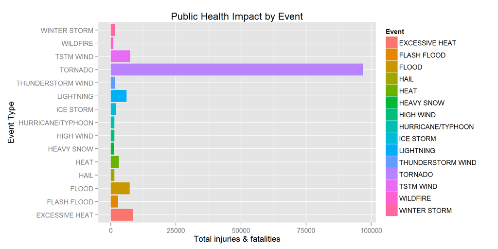

### Economic Impact

**Evaluating the most economically destructive events by TYPE**

```r
library(plyr)
## Calculating aggregate economic damage by Event Type

evProp <- aggregate(rawStorm$PROPDMG, by = list(rawStorm$EVTYPE), FUN = sum)
evCrop <- aggregate(rawStorm$CROPDMG, by = list(rawStorm$EVTYPE), FUN = sum)
evHealth <- cbind(evProp, evCrop[,2])
colnames(evHealth) <- c("Event", "totProp", "totCrop")
evHealth <- mutate(evHealth, totEOuch=apply(evHealth[,2:3], 1, sum))
head(evHealth)
```

```
##                   Event totProp totCrop totEOuch
## 1    HIGH SURF ADVISORY  200000       0   200000
## 2         COASTAL FLOOD       0       0        0
## 3           FLASH FLOOD   50000       0    50000
## 4             LIGHTNING       0       0        0
## 5             TSTM WIND 8100000       0  8100000
## 6       TSTM WIND (G45)    8000       0     8000
```

```r
## Reordering the information to be in descending order
oevHealth <- evHealth[order(evHealth$totEOuch,decreasing=TRUE), ]
sevHealth <- oevHealth[1:15,]

sevHealth$Event <- factor(sevHealth$Event)

head(sevHealth)
```

```
##                 Event   totProp   totCrop  totEOuch
## 170             FLOOD 1.447e+11 5.662e+09 1.503e+11
## 411 HURRICANE/TYPHOON 6.931e+10 2.608e+09 7.191e+10
## 834           TORNADO 5.693e+10 4.150e+08 5.734e+10
## 670       STORM SURGE 4.332e+10 5.000e+03 4.332e+10
## 244              HAIL 1.573e+10 3.026e+09 1.875e+10
## 153       FLASH FLOOD 1.614e+10 1.421e+09 1.756e+10
```

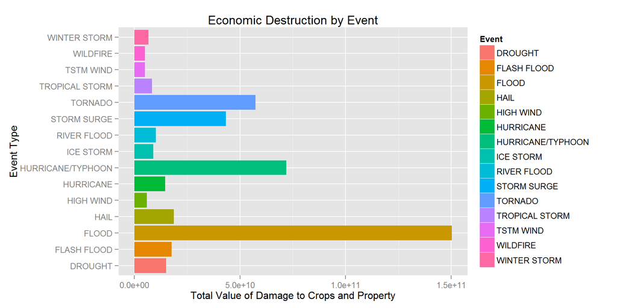

## Results

**Economic**

1. Floods
2. Hurricanes/Typhoons
3. Tornados
4. Storm Surges
5. Hail